# Analysis of Metallica and Coldplay

# Introduction

The tempo of songs is likely to differ between when it is performed live and when it isn’t.A box and whisker plot was used to compare the tempo between live and non-live songs for Metallica.Interesting the tempos have broadly the same mean, with the tempo of live sounds slightly lower.

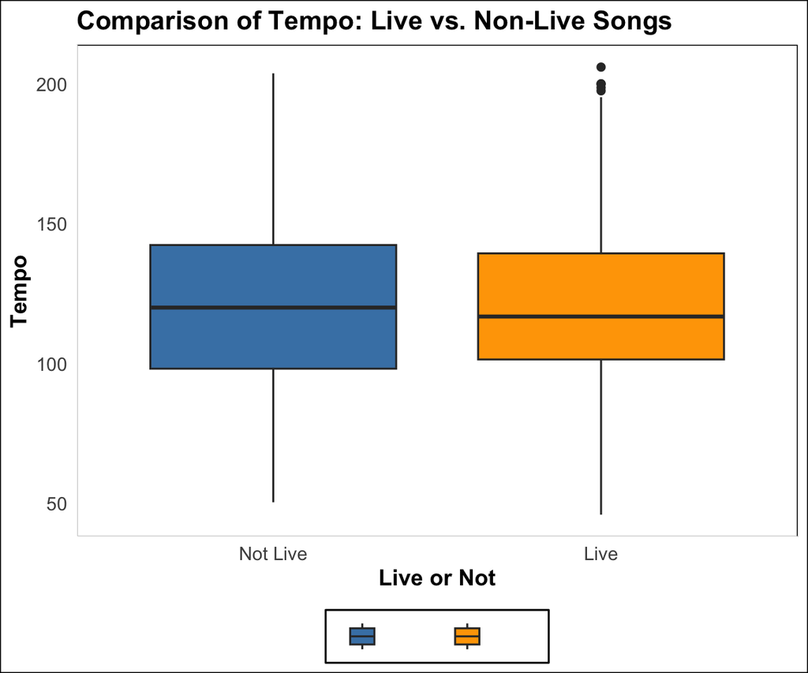

The same comparison was also made for Coldplay. Again the mean of the tempo was broadly similar for both live and non-live songs. However, the box for live song’s tempo was significantly larger than that of non-live.

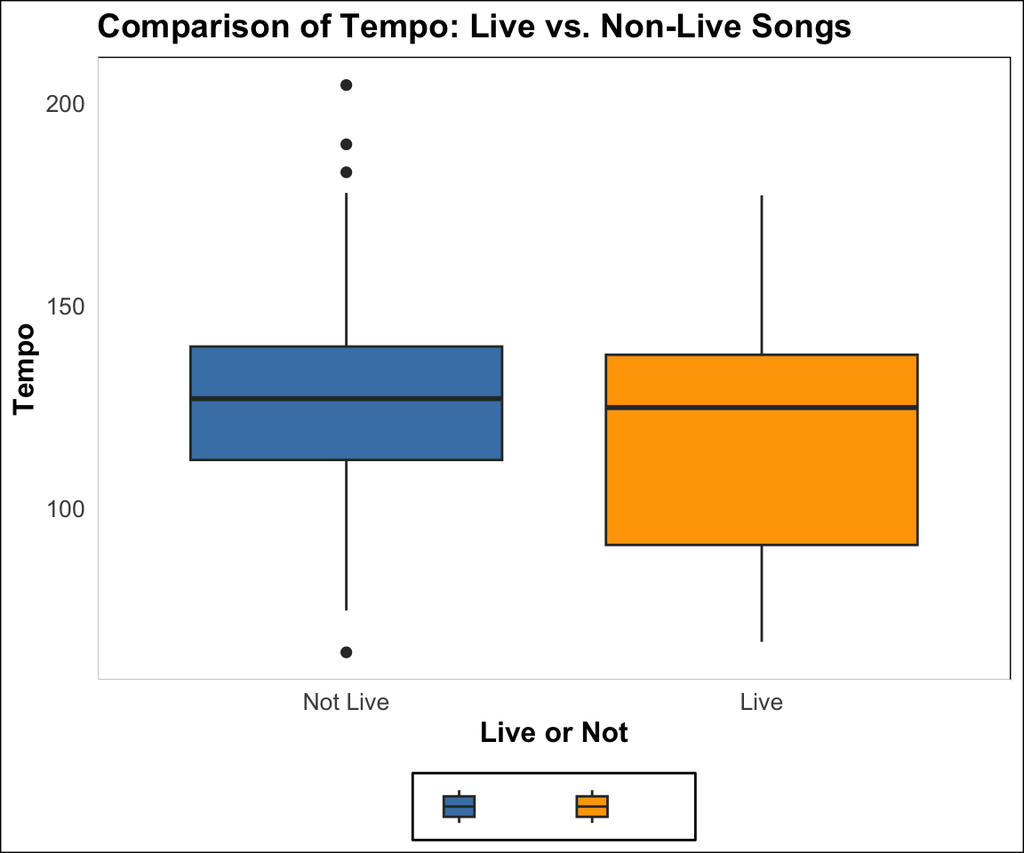

The popularity of Metallica’s songs over time (release date) was plotted using a line plot. Metallica’s initial songs weren’t particularly popular;however, after 1990 their population began to pick up. As time went on, their popularity began to wane again.

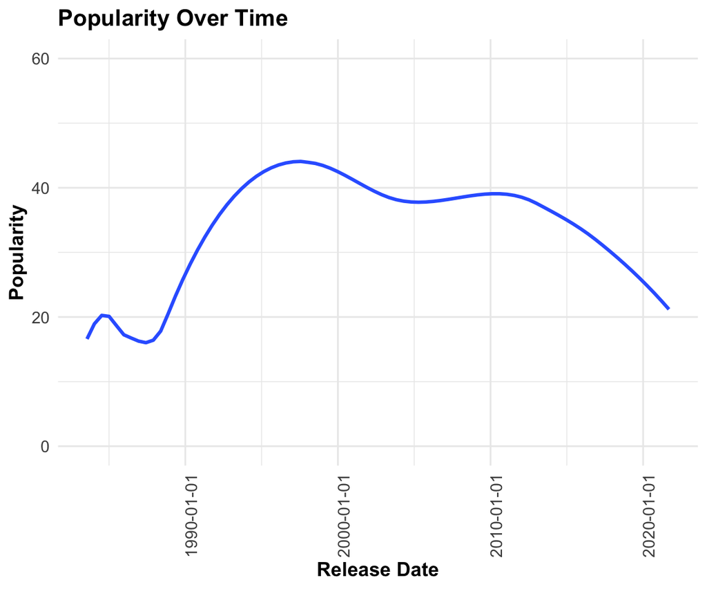

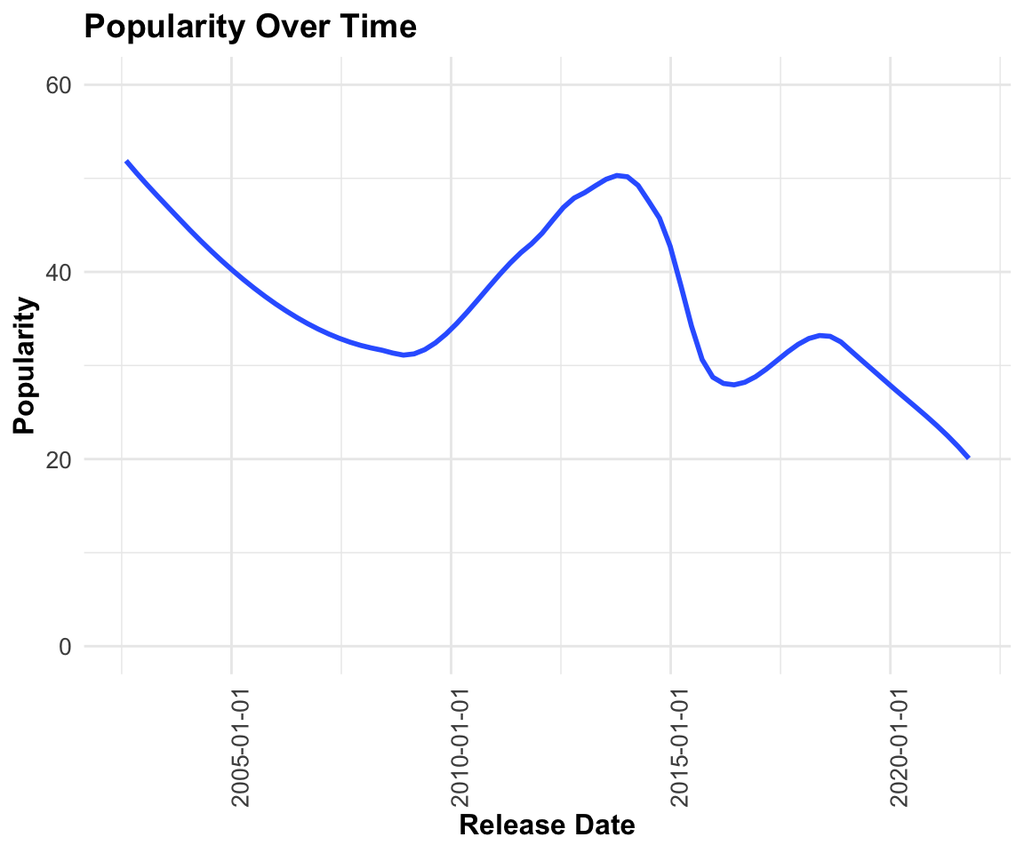

Using the Spotify data, the top ten songs by energy were put into a table alongside their artist. One artist, Cattle Decapitation, appear twice in this top ten list.

```
##
##
## |      |Song                    |Artist              | Energy|
## |:-----|:-----------------------|:-------------------|------:|
## |15866 |Skald av Satans sol     |Darkthrone          |  1.000|
## |39052 |Bizarro Bike            |Lightning Bolt      |  1.000|
## |39193 |Einstein-Rosen Bridge   |Venetian Snares     |  1.000|
## |41284 |The Dressing Room       |Breathe Carolina    |  1.000|
## |43286 |Testicular Manslaughter |Cattle Decapitation |  1.000|
## |43371 |To Serve Man            |Cattle Decapitation |  1.000|
## |48888 |Perverse Party          |Amduscia            |  1.000|
## |49012 |I Am Watching You       |Noisuf-X            |  1.000|
## |3611  |Hedphelym               |Aphex Twin          |  0.999|
## |8332  |ObZen                   |Meshuggah           |  0.999|
```